# Exploration of the NOAA Storm Database

Jonathan Giraldo

11/05/2022

## Synopsis

The goal of this analysis is to answer basic questions about severe weather events using data from the NOAA Storm Database. These questions are about the harmfulness of these events and their economic consequences. It was then found that the most harmful event are Tornadoes, and that the most economically damaging are Floods

## Data Processing

We begin by loading the needed libraries and reading the data, which is stored in the data folder.

```r
library(dplyr)
```

```r
library(ggplot2)
library(gridExtra)
data <- read.csv("./data/repdata_data_StormData.csv")
data$EVTYPE <- as.factor(data$EVTYPE)
head(data)
```

```
##   STATE__           BGN_DATE BGN_TIME TIME_ZONE COUNTY COUNTYNAME STATE  EVTYPE
## 1       1  4/18/1950 0:00:00     0130       CST     97     MOBILE    AL TORNADO
## 2       1  4/18/1950 0:00:00     0145       CST      3    BALDWIN    AL TORNADO
## 3       1  2/20/1951 0:00:00     1600       CST     57    FAYETTE    AL TORNADO
## 4       1   6/8/1951 0:00:00     0900       CST     89    MADISON    AL TORNADO
## 5       1 11/15/1951 0:00:00     1500       CST     43    CULLMAN    AL TORNADO
## 6       1 11/15/1951 0:00:00     2000       CST     77 LAUDERDALE    AL TORNADO
##   BGN_RANGE BGN_AZI BGN_LOCATI END_DATE END_TIME COUNTY_END COUNTYENDN
## 1         0                                               0         NA
## 2         0                                               0         NA
## 3         0                                               0         NA
## 4         0                                               0         NA
## 5         0                                               0         NA
## 6         0                                               0         NA
##   END_RANGE END_AZI END_LOCATI LENGTH WIDTH F MAG FATALITIES INJURIES PROPDMG
```

[output cut: 20 more lines]

```r
health_data <- data[,c("EVTYPE","FATALITIES","INJURIES")]
health_data <- health_data %>% group_by(EVTYPE) %>% summarise(across(everything(),sum))
head(health_data[order(health_data$FATALITIES,decreasing = T),])
```

```
## # A tibble: 6 x 3
##   EVTYPE         FATALITIES INJURIES
##   <fct>               <dbl>    <dbl>
## 1 TORNADO              5633    91346
## 2 EXCESSIVE HEAT       1903     6525
## 3 FLASH FLOOD           978     1777
## 4 HEAT                  937     2100
## 5 LIGHTNING             816     5230
## 6 TSTM WIND             504     6957
```

and then the events that cause the most injuries

```r
head(health_data[order(health_data$INJURIES,decreasing = T),])
```

```
## # A tibble: 6 x 3
##   EVTYPE         FATALITIES INJURIES
##   <fct>               <dbl>    <dbl>
## 1 TORNADO              5633    91346
## 2 TSTM WIND             504     6957
## 3 FLOOD                 470     6789
## 4 EXCESSIVE HEAT       1903     6525
## 5 LIGHTNING             816     5230
## 6 HEAT                  937     2100
```

As we can see, tornadoes cause the highest number of fatalities and injuries. We then take the top seven deadliest events and plot them

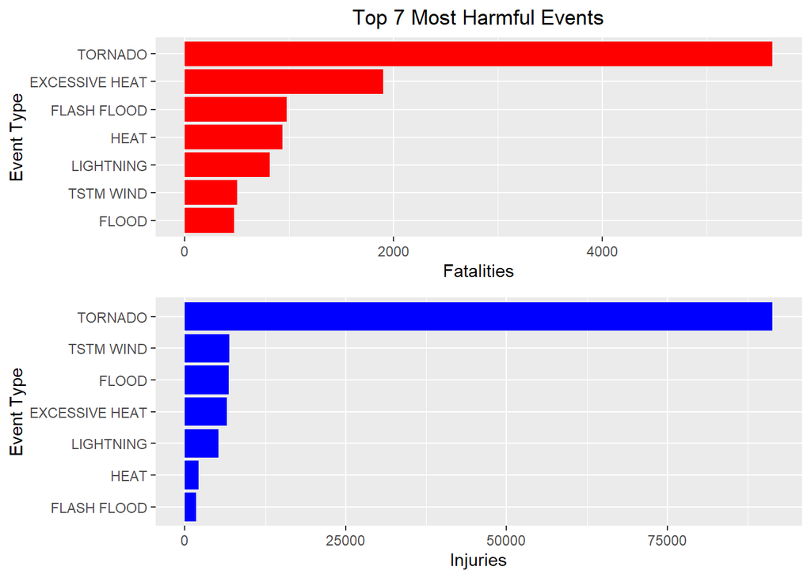

```r
most_harm <- health_data[order(health_data$FATALITIES,decreasing = T),][1:7,]
p1 <- ggplot(data = most_harm,aes(y = reorder(EVTYPE,FATALITIES), x = FATALITIES)) + geom_bar(stat = "identity",fill = "red") + ggtitle("Top 7 Most Harmful Events") + theme(plot.title = element_text(hjust = 0.5)) + ylab("Event Type") + xlab("Fatalities")
p2 <- ggplot(data = most_harm,aes(y = reorder(EVTYPE,INJURIES), x = INJURIES)) + geom_bar(stat = "identity",fill = "blue") + ylab("Event Type") + xlab("Injuries")
grid.arrange(p1,p2,nrow = 2)
```

After analyzing harm to health, we proceed to evaluate economic damage. To analyze both crop damage and property damage we need to put these values in the same scale. The PROPDMGEXP and CROPDMGEXP columns contain the exponent of the PROPDMG and CROPDMG values. Using unique() we see the following:

```r
unique(data$PROPDMGEXP)
```

```
##  [1] "K" "M" ""  "B" "m" "+" "0" "5" "6" "?" "4" "2" "3" "h" "7" "H" "-" "1" "8"
```

```r
unique(data$CROPDMGEXP)
```

```
## [1] ""  "M" "K" "m" "B" "?" "0" "k" "2"
```

Some of these values don’t make sense as exponents and the documentation for the database doesn’t include an explanation for these strange values. We then found this [guide](https://rstudio-pubs-static.s3.amazonaws.com/58957_37b6723ee52b455990e149edde45e5b6.html) that cross-references the data with the official database. We then decided to filter out results that don’t include the H (hundred), K (kilo), M (millions) and B (billions) since in comparison the other values are irrelevant

```r
econ_data <- data[,c("EVTYPE","PROPDMG","PROPDMGEXP","CROPDMG","CROPDMGEXP")]
econ_data <- subset(econ_data,PROPDMGEXP == "H" | PROPDMGEXP == "h"
                    | PROPDMGEXP == "K" | PROPDMGEXP == "k"
                    | PROPDMGEXP == "M" | PROPDMGEXP == "m"
                    | PROPDMGEXP == "B" | PROPDMGEXP == "b"
                    | CROPDMGEXP == "H" | CROPDMGEXP == "h"
                    | CROPDMGEXP == "K" | CROPDMGEXP == "k"
                    | CROPDMGEXP == "M" | CROPDMGEXP == "m"
                    | CROPDMGEXP == "B" | CROPDMGEXP == "b")
```

After filtering, we then multiply or divide the damage costs to compare all values in millions of dollars

```r
for(i in 1:nrow(econ_data)) {

  if(econ_data$PROPDMGEXP[i] == "K" | econ_data$PROPDMGEXP[i] == "k") {
    econ_data$PROPDMG[i] = econ_data$PROPDMG[i] / 1000
  } else if(econ_data$PROPDMGEXP[i] == "B" | econ_data$PROPDMGEXP[i] == "b") {
    econ_data$PROPDMG[i] = econ_data$PROPDMG[i] * 1000
  } else if(econ_data$PROPDMGEXP[i] == "H" | econ_data$PROPDMGEXP[i] == "h") {
    econ_data$PROPDMG[i] = econ_data$PROPDMG[i] / 10000
  }

  if(econ_data$CROPDMGEXP[i] == "K" | econ_data$CROPDMGEXP[i] == "k") {
    econ_data$CROPDMG[i] = econ_data$CROPDMG[i] / 1000
  } else if(econ_data$CROPDMGEXP[i] == "B" | econ_data$CROPDMGEXP[i] == "b") {
    econ_data$CROPDMG[i] = econ_data$CROPDMG[i] * 1000
  } else if(econ_data$CROPDMGEXP[i] == "H" | econ_data$CROPDMGEXP[i] == "h") {
    econ_data$CROPDMG[i] = econ_data$CROPDMG[i] / 10000
  }
}
```

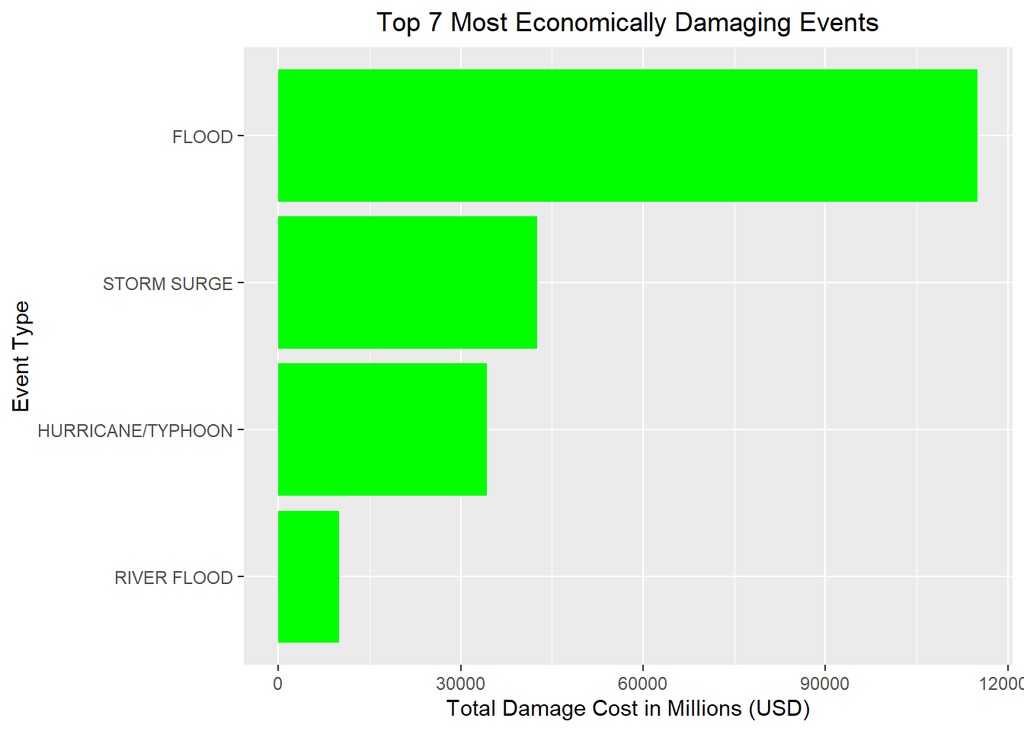

```r
econ_data$TOTALDMG <- econ_data$PROPDMG + econ_data$CROPDMG
total_dmg <- econ_data %>% group_by(EVTYPE) %>% summarise(TOTALDMG = sum(TOTALDMG))
most_dmg <- econ_data[order(econ_data$TOTALDMG,decreasing = T),][1:7,]
ggplot(data = most_dmg,aes(y = reorder(EVTYPE,TOTALDMG), x = TOTALDMG)) + geom_bar(stat = "identity",fill = "green") + ggtitle("Top 7 Most Economically Damaging Events") + theme(plot.title = element_text(hjust = 0.5)) + ylab("Event Type") + xlab("Total Damage Cost in Millions (USD)")
```